# R Notebook-Pepperwood Hobo Data Analysis

```r
knitr::opts_chunk$set(echo = TRUE)
library(ggplot2)
library(dplyr)
```

R Markdown - Individual files

```r
pws <-read.csv("data/PPW_HOBO_2017_Master_Part_May.csv")
str(pws)
```

```
'data.frame':   291772 obs. of  5 variables:
 $ X        : int  51689 51690 51691 51692 51693 51694 51695 51696 51697 51698 ...
 $ Date.Time: Factor w/ 17903 levels "2017-01-01 00:00:00",..: 1 4 7 10 13 16 19 22 25 28 ...
 $ Temp     : num  3.56 3.41 3.35 3.43 3.14 ...
 $ RH       : num  99.7 99.9 100 100 100 ...
 $ Plot     : int  1301 1301 1301 1301 1301 1301 1301 1301 1301 1301 ...
```

```r
summary(pws)
```

```
       X                         Date.Time           Temp              RH
 Min.   :  51689   2017-01-01 00:00:00:    48   Min.   :-3.271   Min.   :  9.237
 1st Qu.: 825657   2017-01-01 00:30:00:    48   1st Qu.: 6.864   1st Qu.: 75.261
 Median :1642052   2017-01-01 01:00:00:    48   Median : 9.952   Median : 94.260
 Mean   :1611543   2017-01-01 01:30:00:    48   Mean   :10.167   Mean   : 85.310
 3rd Qu.:2403411   2017-01-01 02:00:00:    48   3rd Qu.:12.558   3rd Qu.:100.000
 Max.   :3157961   2017-01-01 02:30:00:    48   Max.   :32.355   Max.   :100.000
                   (Other)            :291484   NA's   :157      NA's   :157
      Plot
 Min.   :1301
 1st Qu.:1313
 Median :1326
 Mean   :1326
 3rd Qu.:1338
 Max.   :1350
```

Check the imported columns

```r
str(pws)
```

```
'data.frame':   291772 obs. of  5 variables:
 $ X        : int  51689 51690 51691 51692 51693 51694 51695 51696 51697 51698 ...
 $ Date.Time: Factor w/ 17903 levels "2017-01-01 00:00:00",..: 1 4 7 10 13 16 19 22 25 28 ...
 $ Temp     : num  3.56 3.41 3.35 3.43 3.14 ...
 $ RH       : num  99.7 99.9 100 100 100 ...
 $ Plot     : int  1301 1301 1301 1301 1301 1301 1301 1301 1301 1301 ...
```

```r
head(pws)
```

|  | X | Date.Time | Temp | RH | Plot |
| --- | --- | --- | --- | --- | --- |
| 1 | 51689 | 2017-01-01 00:00:00 | 3.564 | 99.663 | 1301 |
| 2 | 51690 | 2017-01-01 00:30:00 | 3.406 | 99.905 | 1301 |
| 3 | 51691 | 2017-01-01 01:00:00 | 3.354 | 99.985 | 1301 |
| 4 | 51692 | 2017-01-01 01:30:00 | 3.433 | 100.000 | 1301 |
| 5 | 51693 | 2017-01-01 02:00:00 | 3.142 | 100.000 | 1301 |
| 6 | 51694 | 2017-01-01 02:30:00 | 3.485 | 100.000 | 1301 |

```r
pws$tsfmt<- as.POSIXct(pws$Date.Time,format="%Y-%m-%d %H:%M:%S")
head(pws)
```

|  | X | Date.Time | Temp | RH | Plot | tsfmt |
| --- | --- | --- | --- | --- | --- | --- |
| 1 | 51689 | 2017-01-01 00:00:00 | 3.564 | 99.663 | 1301 | 2017-01-01 00:00:00 |
| 2 | 51690 | 2017-01-01 00:30:00 | 3.406 | 99.905 | 1301 | 2017-01-01 00:30:00 |
| 3 | 51691 | 2017-01-01 01:00:00 | 3.354 | 99.985 | 1301 | 2017-01-01 01:00:00 |
| 4 | 51692 | 2017-01-01 01:30:00 | 3.433 | 100.000 | 1301 | 2017-01-01 01:30:00 |
| 5 | 51693 | 2017-01-01 02:00:00 | 3.142 | 100.000 | 1301 | 2017-01-01 02:00:00 |
| 6 | 51694 | 2017-01-01 02:30:00 | 3.485 | 100.000 | 1301 | 2017-01-01 02:30:00 |

Lets try to do the summary by site, day for the 2017 data for RH and Temperature

```r
head(pws %>%mutate(HR= format(tsfmt,"%H"),DATE=format(tsfmt,"%Y-%m-%d")) %>% group_by(Plot,DATE,HR) %>% summarise(minHrlyTemp = min(Temp),maxHrlyTemp = max(Temp),meanHrlyTemp = mean(Temp),minHrlyRH = min(RH),maxHrlyRH = max(RH),meanHrlyRH = mean(RH)) %>% as.data.frame())
```

|  | Plot | DATE | HR | minHrlyTemp | maxHrlyTemp | meanHrlyTemp | minHrlyRH | maxHrlyRH | meanHrlyRH |
| --- | --- | --- | --- | --- | --- | --- | --- | --- | --- |
| 1 | 1301 | 2017-01-01 | 00 | 3.406 | 3.564 | 3.4850 | 99.663 | 99.905 | 99.7840 |
| 2 | 1301 | 2017-01-01 | 01 | 3.354 | 3.433 | 3.3935 | 99.985 | 100.000 | 99.9925 |
| 3 | 1301 | 2017-01-01 | 02 | 3.142 | 3.485 | 3.3135 | 100.000 | 100.000 | 100.0000 |
| 4 | 1301 | 2017-01-01 | 03 | 3.221 | 3.354 | 3.2875 | 100.000 | 100.000 | 100.0000 |
| 5 | 1301 | 2017-01-01 | 04 | 2.182 | 2.584 | 2.3830 | 99.882 | 100.000 | 99.9410 |
| 6 | 1301 | 2017-01-01 | 05 | 3.512 | 3.749 | 3.6305 | 100.000 | 100.000 | 100.0000 |

Lets write to CSV

```r
pws %>%mutate(HR= format(tsfmt,"%H"),DATE=format(tsfmt,"%Y-%m-%d")) %>% group_by(Plot,DATE,HR) %>% summarise(minHrlyTemp = min(Temp),maxHrlyTemp = max(Temp),meanHrlyTemp = mean(Temp),minHrlyRH = min(RH),maxHrlyRH = max(RH),meanHrlyRH = mean(RH)) %>% as.data.frame() %>% write.csv("data/Hobo-2017-Summary-Hourly.csv")
```

Now, lets create the daily file. We can follow the same, but now summarize by DATE

```r
pws %>%mutate(HR= format(tsfmt,"%H"),DATE=format(tsfmt,"%Y-%m-%d")) %>% group_by(Plot,DATE) %>% summarise(minHrlyTemp = min(Temp),maxHrlyTemp = max(Temp),maxHrlyTemp = max(Temp),minHrlyRH = min(RH),maxHrlyRH = max(RH),meanHrlyRH = mean(RH)) %>% as.data.frame() %>% write.csv("data/Hobo-2017-Summary-Daily.csv")
```

Lets validate our files, criteria a) Number of collection points

```r
ht2017<- read.csv('./data/Hobo-2017-Summary-Hourly.csv')
str(ht2017)
```

```
'data.frame':   141548 obs. of  10 variables:
 $ X           : int  1 2 3 4 5 6 7 8 9 10 ...
 $ Plot        : int  1301 1301 1301 1301 1301 1301 1301 1301 1301 1301 ...
 $ DATE        : Factor w/ 124 levels "2017-01-01","2017-01-02",..: 1 1 1 1 1 1 1 1 1 1 ...
 $ HR          : int  0 1 2 3 4 5 6 7 8 9 ...
 $ minHrlyTemp : num  3.41 3.35 3.14 3.22 2.18 ...
 $ maxHrlyTemp : num  3.56 3.43 3.48 3.35 2.58 ...
 $ meanHrlyTemp: num  3.48 3.39 3.31 3.29 2.38 ...
 $ minHrlyRH   : num  99.7 100 100 100 99.9 ...
 $ maxHrlyRH   : num  99.9 100 100 100 100 ...
 $ meanHrlyRH  : num  99.8 100 100 100 99.9 ...
```

```r
head(ht2017)
```

|  | X | Plot | DATE | HR | minHrlyTemp | maxHrlyTemp | meanHrlyTemp | minHrlyRH | maxHrlyRH | meanHrlyRH |
| --- | --- | --- | --- | --- | --- | --- | --- | --- | --- | --- |
| 1 | 1 | 1301 | 2017-01-01 | 0 | 3.406 | 3.564 | 3.4850 | 99.663 | 99.905 | 99.7840 |
| 2 | 2 | 1301 | 2017-01-01 | 1 | 3.354 | 3.433 | 3.3935 | 99.985 | 100.000 | 99.9925 |
| 3 | 3 | 1301 | 2017-01-01 | 2 | 3.142 | 3.485 | 3.3135 | 100.000 | 100.000 | 100.0000 |
| 4 | 4 | 1301 | 2017-01-01 | 3 | 3.221 | 3.354 | 3.2875 | 100.000 | 100.000 | 100.0000 |
| 5 | 5 | 1301 | 2017-01-01 | 4 | 2.182 | 2.584 | 2.3830 | 99.882 | 100.000 | 99.9410 |
| 6 | 6 | 1301 | 2017-01-01 | 5 | 3.512 | 3.749 | 3.6305 | 100.000 | 100.000 | 100.0000 |

Housekeeping , convert date from factor to a datetype, and add Month

```r
ht2017$dt <- as.Date(ht2017$DATE, "%Y-%m-%d")
str(ht2017)
```

```
'data.frame':   141548 obs. of  11 variables:
 $ X           : int  1 2 3 4 5 6 7 8 9 10 ...
 $ Plot        : int  1301 1301 1301 1301 1301 1301 1301 1301 1301 1301 ...
 $ DATE        : Factor w/ 124 levels "2017-01-01","2017-01-02",..: 1 1 1 1 1 1 1 1 1 1 ...
 $ HR          : int  0 1 2 3 4 5 6 7 8 9 ...
 $ minHrlyTemp : num  3.41 3.35 3.14 3.22 2.18 ...
 $ maxHrlyTemp : num  3.56 3.43 3.48 3.35 2.58 ...
 $ meanHrlyTemp: num  3.48 3.39 3.31 3.29 2.38 ...
 $ minHrlyRH   : num  99.7 100 100 100 99.9 ...
 $ maxHrlyRH   : num  99.9 100 100 100 100 ...
 $ meanHrlyRH  : num  99.8 100 100 100 99.9 ...
 $ dt          : Date, format: "2017-01-01" "2017-01-01" ...
```

```r
# Check for the Sanity of data
summary(ht2017)
```

```
       X               Plot              DATE              HR
 Min.   :     1   Min.   :1301   2017-02-25:  1176   Min.   : 0.00
 1st Qu.: 35388   1st Qu.:1313   2017-02-26:  1176   1st Qu.: 5.00
 Median : 70774   Median :1326   2017-02-27:  1176   Median :11.00
 Mean   : 70774   Mean   :1325   2017-02-28:  1176   Mean   :11.48
 3rd Qu.:106161   3rd Qu.:1338   2017-03-01:  1176   3rd Qu.:17.00
 Max.   :141548   Max.   :1350   2017-03-02:  1176   Max.   :23.00
                                 (Other)   :134492
  minHrlyTemp      maxHrlyTemp      meanHrlyTemp      minHrlyRH
 Min.   :-3.271   Min.   :-3.153   Min.   :-3.212   Min.   :  9.237
 1st Qu.: 6.712   1st Qu.: 7.116   1st Qu.: 6.902   1st Qu.: 73.280
 Median : 9.780   Median :10.149   Median : 9.963   Median : 93.273
 Mean   : 9.943   Mean   :10.411   Mean   :10.177   Mean   : 84.319
 3rd Qu.:12.340   3rd Qu.:12.775   3rd Qu.:12.557   3rd Qu.:100.000
 Max.   :31.996   Max.   :32.355   Max.   :32.086   Max.   :100.000
 NA's   :73       NA's   :73       NA's   :73       NA's   :73
   maxHrlyRH        meanHrlyRH           dt
 Min.   : 10.32   Min.   : 10.14   Min.   :2017-01-01
 1st Qu.: 77.18   1st Qu.: 75.25   1st Qu.:2017-01-31
 Median : 95.12   Median : 94.15   Median :2017-03-03
 Mean   : 86.23   Mean   : 85.28   Mean   :2017-03-02
 3rd Qu.:100.00   3rd Qu.:100.00   3rd Qu.:2017-04-02
 Max.   :100.00   Max.   :100.00   Max.   :2017-05-04
 NA's   :73       NA's   :73
```

Looks ok except for NAs, research the issue

```r
ht2017$dt <- as.Date(ht2017$DATE, "%Y-%m-%d")
str(ht2017)
```

```
'data.frame':   141548 obs. of  11 variables:
 $ X           : int  1 2 3 4 5 6 7 8 9 10 ...
 $ Plot        : int  1301 1301 1301 1301 1301 1301 1301 1301 1301 1301 ...
 $ DATE        : Factor w/ 124 levels "2017-01-01","2017-01-02",..: 1 1 1 1 1 1 1 1 1 1 ...
 $ HR          : int  0 1 2 3 4 5 6 7 8 9 ...
 $ minHrlyTemp : num  3.41 3.35 3.14 3.22 2.18 ...
 $ maxHrlyTemp : num  3.56 3.43 3.48 3.35 2.58 ...
 $ meanHrlyTemp: num  3.48 3.39 3.31 3.29 2.38 ...
 $ minHrlyRH   : num  99.7 100 100 100 99.9 ...
 $ maxHrlyRH   : num  99.9 100 100 100 100 ...
 $ meanHrlyRH  : num  99.8 100 100 100 99.9 ...
 $ dt          : Date, format: "2017-01-01" "2017-01-01" ...
```

```r
# Check for the Sanity of data
summary(ht2017)
```

```
       X               Plot              DATE              HR
 Min.   :     1   Min.   :1301   2017-02-25:  1176   Min.   : 0.00
 1st Qu.: 35388   1st Qu.:1313   2017-02-26:  1176   1st Qu.: 5.00
 Median : 70774   Median :1326   2017-02-27:  1176   Median :11.00
 Mean   : 70774   Mean   :1325   2017-02-28:  1176   Mean   :11.48
 3rd Qu.:106161   3rd Qu.:1338   2017-03-01:  1176   3rd Qu.:17.00
 Max.   :141548   Max.   :1350   2017-03-02:  1176   Max.   :23.00
                                 (Other)   :134492
  minHrlyTemp      maxHrlyTemp      meanHrlyTemp      minHrlyRH
 Min.   :-3.271   Min.   :-3.153   Min.   :-3.212   Min.   :  9.237
 1st Qu.: 6.712   1st Qu.: 7.116   1st Qu.: 6.902   1st Qu.: 73.280
 Median : 9.780   Median :10.149   Median : 9.963   Median : 93.273
 Mean   : 9.943   Mean   :10.411   Mean   :10.177   Mean   : 84.319
 3rd Qu.:12.340   3rd Qu.:12.775   3rd Qu.:12.557   3rd Qu.:100.000
 Max.   :31.996   Max.   :32.355   Max.   :32.086   Max.   :100.000
 NA's   :73       NA's   :73       NA's   :73       NA's   :73
   maxHrlyRH        meanHrlyRH           dt
 Min.   : 10.32   Min.   : 10.14   Min.   :2017-01-01
 1st Qu.: 77.18   1st Qu.: 75.25   1st Qu.:2017-01-31
 Median : 95.12   Median : 94.15   Median :2017-03-03
 Mean   : 86.23   Mean   : 85.28   Mean   :2017-03-02
 3rd Qu.:100.00   3rd Qu.:100.00   3rd Qu.:2017-04-02
 Max.   :100.00   Max.   :100.00   Max.   :2017-05-04
 NA's   :73       NA's   :73
```

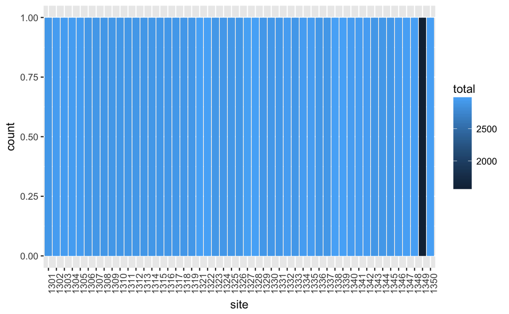

```r
ht2017 %>% mutate(site = as.factor(Plot)) %>%
group_by(site) %>%
summarise(total = n()) %>% ggplot(aes(x=site,fill=total)) +
geom_bar() +
theme(axis.text.x = element_text(angle = 90, hjust = 1))
```

Different way of looking at same, we expect for each plot 24 points for a day, so that makes it 24*365 (approx 8760 points for a site) . We get 2 by site every hour.

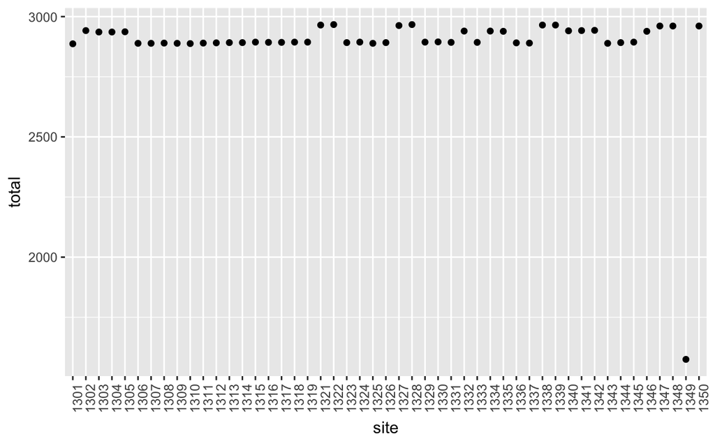

```r
ht2017 %>%  mutate(site = as.factor(Plot)) %>%
group_by(site) %>%
summarise(total = n()) %>% ggplot(aes(x=site,y=total)) +
geom_point() +
theme(axis.text.x = element_text(angle = 90, hjust = 1))
```

Now, lets look at the unusually high temperatures

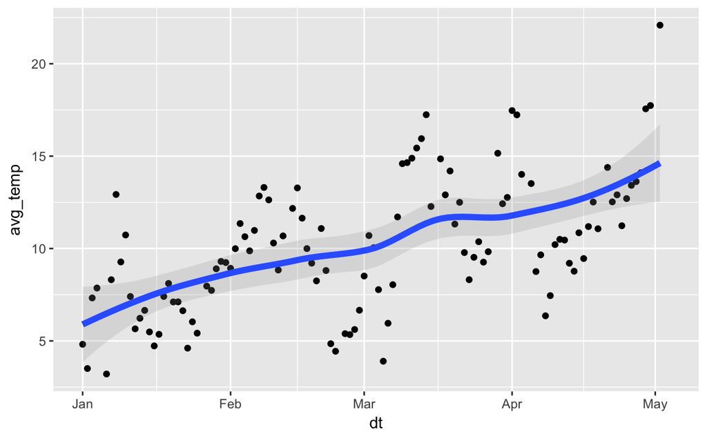

```r
ht2017 %>% group_by(dt)  %>% summarise(avg_temp=mean(meanHrlyTemp)) %>% ggplot(aes(dt,avg_temp)) +
geom_point() + geom_smooth(alpha=.2, size=2)
```

So, mostly looks good, lets look at it closer. Nice curve showing the increase in temperatures towards summer

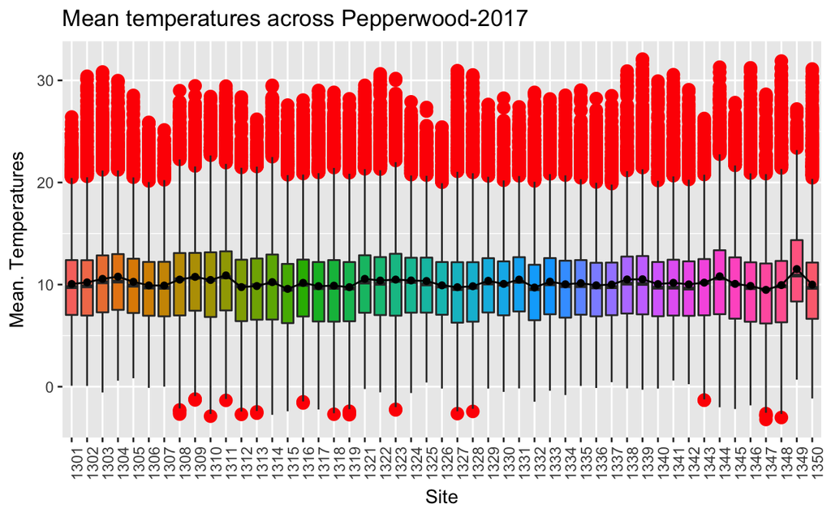

```r
p1 <- ggplot(ht2017, aes(factor(Plot), meanHrlyTemp))
p1 <- p1 + geom_boxplot(aes(fill = factor(Plot)),outlier.colour = "red", outlier.size = 3) + theme(axis.text.x = element_text(angle = 90, hjust = 1),legend.position="none") + ggtitle("Mean temperatures across Pepperwood-2017") + xlab("Site") +
ylab("Mean. Temperatures")+ stat_summary(fun.y=mean, geom="line", aes(group=1))  +
stat_summary(fun.y=mean, geom="point")
p1
```

Issue with 1349 , putting it all out of whack.

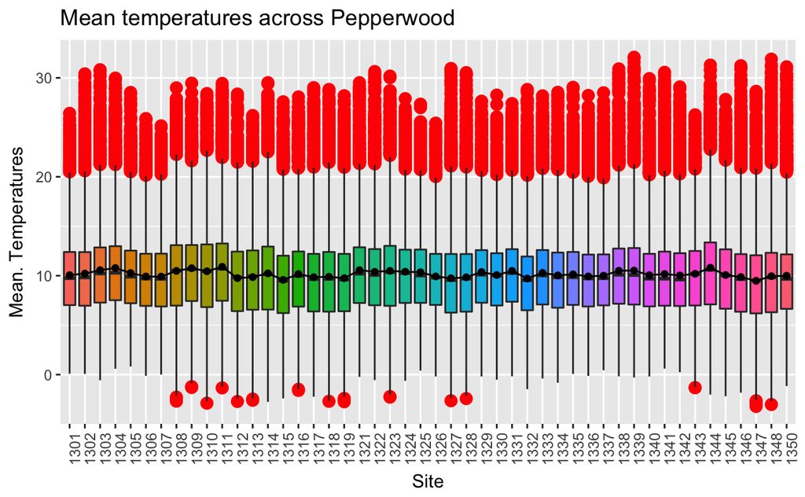

```r
p1 <- ggplot(ht2017 %>% filter(!(Plot %in% c(1349))), aes(factor(Plot), meanHrlyTemp))
p1 <- p1 + geom_boxplot(aes(fill = factor(Plot)),outlier.colour = "red", outlier.size = 3) + theme(axis.text.x = element_text(angle = 90, hjust = 1),legend.position="none") + ggtitle("Mean temperatures across Pepperwood") + xlab("Site") +
ylab("Mean. Temperatures")+ stat_summary(fun.y=mean, geom="line", aes(group=1))  +
stat_summary(fun.y=mean, geom="point")
p1
```

```r
str(ht2017)
```

```
'data.frame':   141548 obs. of  11 variables:
 $ X           : int  1 2 3 4 5 6 7 8 9 10 ...
 $ Plot        : int  1301 1301 1301 1301 1301 1301 1301 1301 1301 1301 ...
 $ DATE        : Factor w/ 124 levels "2017-01-01","2017-01-02",..: 1 1 1 1 1 1 1 1 1 1 ...
 $ HR          : int  0 1 2 3 4 5 6 7 8 9 ...
 $ minHrlyTemp : num  3.41 3.35 3.14 3.22 2.18 ...
 $ maxHrlyTemp : num  3.56 3.43 3.48 3.35 2.58 ...
 $ meanHrlyTemp: num  3.48 3.39 3.31 3.29 2.38 ...
 $ minHrlyRH   : num  99.7 100 100 100 99.9 ...
 $ maxHrlyRH   : num  99.9 100 100 100 100 ...
 $ meanHrlyRH  : num  99.8 100 100 100 99.9 ...
 $ dt          : Date, format: "2017-01-01" "2017-01-01" ...
```

```r
head(ht2017 %>% mutate(MONTH= format(dt,"%m"),DAY= format(dt,"%d")) %>% as.data.frame())
```

|  | X | Plot | DATE | HR | minHrlyTemp | maxHrlyTemp | meanHrlyTemp | minHrlyRH | maxHrlyRH | meanHrlyRH | dt | MONTH | DAY |
| --- | --- | --- | --- | --- | --- | --- | --- | --- | --- | --- | --- | --- | --- |
| 1 | 1 | 1301 | 2017-01-01 | 0 | 3.406 | 3.564 | 3.4850 | 99.663 | 99.905 | 99.7840 | 2017-01-01 | 01 | 01 |
| 2 | 2 | 1301 | 2017-01-01 | 1 | 3.354 | 3.433 | 3.3935 | 99.985 | 100.000 | 99.9925 | 2017-01-01 | 01 | 01 |
| 3 | 3 | 1301 | 2017-01-01 | 2 | 3.142 | 3.485 | 3.3135 | 100.000 | 100.000 | 100.0000 | 2017-01-01 | 01 | 01 |
| 4 | 4 | 1301 | 2017-01-01 | 3 | 3.221 | 3.354 | 3.2875 | 100.000 | 100.000 | 100.0000 | 2017-01-01 | 01 | 01 |
| 5 | 5 | 1301 | 2017-01-01 | 4 | 2.182 | 2.584 | 2.3830 | 99.882 | 100.000 | 99.9410 | 2017-01-01 | 01 | 01 |
| 6 | 6 | 1301 | 2017-01-01 | 5 | 3.512 | 3.749 | 3.6305 | 100.000 | 100.000 | 100.0000 | 2017-01-01 | 01 | 01 |

```r
str(ht2017)
```

```
'data.frame':   141548 obs. of  11 variables:
 $ X           : int  1 2 3 4 5 6 7 8 9 10 ...
 $ Plot        : int  1301 1301 1301 1301 1301 1301 1301 1301 1301 1301 ...
 $ DATE        : Factor w/ 124 levels "2017-01-01","2017-01-02",..: 1 1 1 1 1 1 1 1 1 1 ...
 $ HR          : int  0 1 2 3 4 5 6 7 8 9 ...
 $ minHrlyTemp : num  3.41 3.35 3.14 3.22 2.18 ...
 $ maxHrlyTemp : num  3.56 3.43 3.48 3.35 2.58 ...
 $ meanHrlyTemp: num  3.48 3.39 3.31 3.29 2.38 ...
 $ minHrlyRH   : num  99.7 100 100 100 99.9 ...
 $ maxHrlyRH   : num  99.9 100 100 100 100 ...
 $ meanHrlyRH  : num  99.8 100 100 100 99.9 ...
 $ dt          : Date, format: "2017-01-01" "2017-01-01" ...
```

```r
head(ht2017 %>% mutate(MONTH= format(dt,"%m"),DAY= format(dt,"%d")) %>% as.data.frame())
```

|  | X | Plot | DATE | HR | minHrlyTemp | maxHrlyTemp | meanHrlyTemp | minHrlyRH | maxHrlyRH | meanHrlyRH | dt | MONTH | DAY |
| --- | --- | --- | --- | --- | --- | --- | --- | --- | --- | --- | --- | --- | --- |
| 1 | 1 | 1301 | 2017-01-01 | 0 | 3.406 | 3.564 | 3.4850 | 99.663 | 99.905 | 99.7840 | 2017-01-01 | 01 | 01 |
| 2 | 2 | 1301 | 2017-01-01 | 1 | 3.354 | 3.433 | 3.3935 | 99.985 | 100.000 | 99.9925 | 2017-01-01 | 01 | 01 |
| 3 | 3 | 1301 | 2017-01-01 | 2 | 3.142 | 3.485 | 3.3135 | 100.000 | 100.000 | 100.0000 | 2017-01-01 | 01 | 01 |
| 4 | 4 | 1301 | 2017-01-01 | 3 | 3.221 | 3.354 | 3.2875 | 100.000 | 100.000 | 100.0000 | 2017-01-01 | 01 | 01 |
| 5 | 5 | 1301 | 2017-01-01 | 4 | 2.182 | 2.584 | 2.3830 | 99.882 | 100.000 | 99.9410 | 2017-01-01 | 01 | 01 |
| 6 | 6 | 1301 | 2017-01-01 | 5 | 3.512 | 3.749 | 3.6305 | 100.000 | 100.000 | 100.0000 | 2017-01-01 | 01 | 01 |

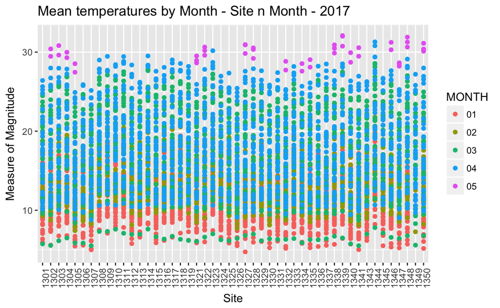

```r
ht2017$site<- as.factor(ht2017$Plot)
ht2017 %>% filter(!(Plot %in% c(1342))) %>% mutate(MONTH= format(dt,"%m"),DAY= format(dt,"%d")) %>% filter(MONTH %in% c('01','02','03','04','05','06','07','08','09','10','11','12')) %>% group_by(site,MONTH,DAY) %>%
    summarise(
              min_temp = min(meanHrlyTemp),
              max_temp = max(meanHrlyTemp),
              mean_temp = max(meanHrlyTemp),
              diu_fluct = max_temp - min_temp ,
              total = n()) %>% ggplot(aes(site,mean_temp, color=MONTH)) + geom_point() +  theme(axis.text.x = element_text(angle = 90, hjust = 1)) + ggtitle("Mean temperatures by Month - Site n Month - 2017") + xlab("Site") + ylab("Measure of Magnitude")
```

Looks ok, lets look at daily Diurnal fluctuation

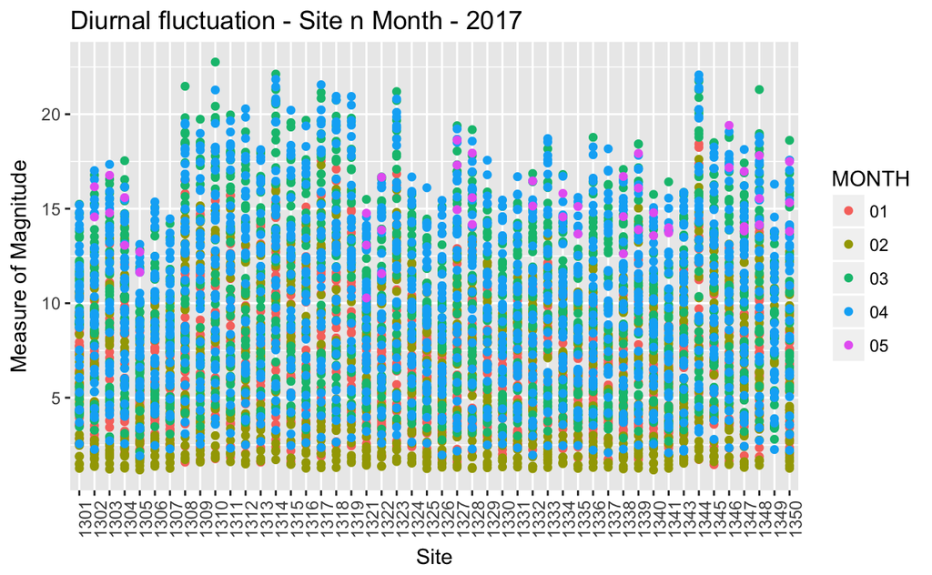

```r
ht2017$site<- as.factor(ht2017$Plot)
ht2017 %>% filter(!(Plot %in% c(1342))) %>% mutate(MONTH= format(dt,"%m"),DAY= format(dt,"%d")) %>% filter(MONTH %in% c('01','02','03','04','05','06','07','08','09','10','11','12')) %>% group_by(site,MONTH,DAY) %>%
    summarise(
              min_temp = min(meanHrlyTemp),
              max_temp = max(meanHrlyTemp),
              diu_fluct = max_temp - min_temp ,
              total = n()) %>% ggplot(aes(site,diu_fluct, color=MONTH)) + geom_point() +  theme(axis.text.x = element_text(angle = 90, hjust = 1)) + ggtitle("Diurnal fluctuation - Site n Month - 2017") + xlab("Site") + ylab("Measure of Magnitude")
```